# Identifying Fraud from Enron Emails and Financial Data

## Project Overview

In 2000, Enron was one of the largest companies in the United States. By 2002, it had collapsed into bankruptcy due to widespread corporate fraud. In the resulting Federal investigation, a significant amount of typically confidential information entered into the public record, including tens of thousands of emails and detailed financial data for top executives. In this project, you will play detective, and put your new skills to use by building a person of interest identifier based on financial and email data made public as a result of the Enron scandal. To assist you in your detective work, we've combined this data with a hand-generated list of persons of interest in the fraud case, which means individuals who were indicted, reached a settlement or plea deal with the government, or testified in exchange for prosecution immunity.

## Data Exploration and Outlier Investigation

```python
import sys
import pickle
sys.path.append("../tools/")

from feature_format import featureFormat, targetFeatureSplit
from tester import dump_classifier_and_data

import numpy as np
import pandas as pd

import matplotlib.pyplot as plt
%matplotlib inline
```

```python
### Load the dictionary containing the dataset
with open("final_project_dataset.pkl", "r") as data_file:
    data_dict = pickle.load(data_file)
```

```python
df = pd.DataFrame.from_dict(data_dict, orient='index')
df = df.replace('NaN', np.nan)
```

```python
df['poi'].count()
```

```
146
```

There are 146 records in total.

```python
df.loc[df.poi == True, 'poi'].count()
```

```
18
```

Within 146 records, there are 18 POIs.

```python
float(18)/(146-18)
```

```
0.140625
```

```python
len(df.columns)
```

```
21
```

There are 146 peole in the dataset with 18 person of interest. The allocation across classes is 0.14. The # of features of each person are 21.

```python
df.info()
```

```
<class 'pandas.core.frame.DataFrame'>
Index: 146 entries, ALLEN PHILLIP K to YEAP SOON
Data columns (total 21 columns):
salary                       95 non-null float64
to_messages                  86 non-null float64
deferral_payments            39 non-null float64
total_payments               125 non-null float64
exercised_stock_options      102 non-null float64
bonus                        82 non-null float64
restricted_stock             110 non-null float64
shared_receipt_with_poi      86 non-null float64
restricted_stock_deferred    18 non-null float64
total_stock_value            126 non-null float64
expenses                     95 non-null float64
loan_advances                4 non-null float64
from_messages                86 non-null float64
other                        93 non-null float64
from_this_person_to_poi      86 non-null float64
poi                          146 non-null bool
director_fees                17 non-null float64
deferred_income              49 non-null float64
long_term_incentive          66 non-null float64
email_address                111 non-null object
from_poi_to_this_person      86 non-null float64
dtypes: bool(1), float64(19), object(1)
memory usage: 24.1+ KB
```

As you can see from info, there are many null values in the table.

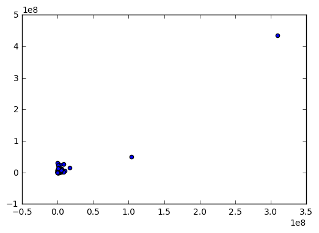

```python
plt.scatter(df.total_payments,df.total_stock_value)
```

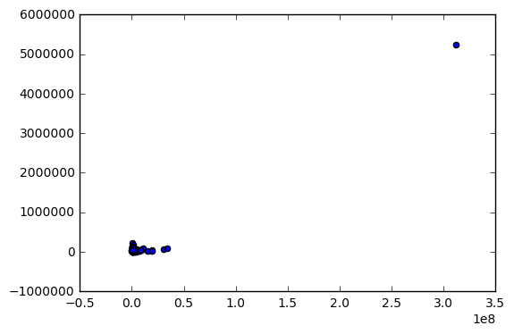

```python
plt.scatter(df.exercised_stock_options,df.expenses)
```

I selected 4 numeric features with less nulls to do the scatter plot. As we could see in the plot, there is one outlier. Let's see what it is.

```python
df[df.total_payments > 3.0e8]
```

|  | salary | to_messages | deferral_payments | total_payments | exercised_stock_options | bonus | restricted_stock | shared_receipt_with_poi | restricted_stock_deferred | total_stock_value | ... | loan_advances | from_messages | other | from_this_person_to_poi | poi | director_fees | deferred_income | long_term_incentive | email_address | from_poi_to_this_person |
| --- | --- | --- | --- | --- | --- | --- | --- | --- | --- | --- | --- | --- | --- | --- | --- | --- | --- | --- | --- | --- | --- |
| TOTAL | 26704229.0 | NaN | 32083396.0 | 309886585.0 | 311764000.0 | 97343619.0 | 130322299.0 | NaN | -7576788.0 | 434509511.0 | ... | 83925000.0 | NaN | 42667589.0 | NaN | False | 1398517.0 | -27992891.0 | 48521928.0 | NaN | NaN |

1 rows × 21 columns

```python
df[df.exercised_stock_options > 3.0e8]
```

|  | salary | to_messages | deferral_payments | total_payments | exercised_stock_options | bonus | restricted_stock | shared_receipt_with_poi | restricted_stock_deferred | total_stock_value | ... | loan_advances | from_messages | other | from_this_person_to_poi | poi | director_fees | deferred_income | long_term_incentive | email_address | from_poi_to_this_person |
| --- | --- | --- | --- | --- | --- | --- | --- | --- | --- | --- | --- | --- | --- | --- | --- | --- | --- | --- | --- | --- | --- |
| TOTAL | 26704229.0 | NaN | 32083396.0 | 309886585.0 | 311764000.0 | 97343619.0 | 130322299.0 | NaN | -7576788.0 | 434509511.0 | ... | 83925000.0 | NaN | 42667589.0 | NaN | False | 1398517.0 | -27992891.0 | 48521928.0 | NaN | NaN |

1 rows × 21 columns

As we can see in the result, the outlier is "Total" records within this 146 records. This is a very common mistake when prepared the dataset. So I'm going to remove it.

```python
# Delete "Total" row
df = df.drop(['TOTAL'])
```

```python
df.info()
```

```
<class 'pandas.core.frame.DataFrame'>
Index: 145 entries, ALLEN PHILLIP K to YEAP SOON
Data columns (total 21 columns):
salary                       94 non-null float64
to_messages                  86 non-null float64
deferral_payments            38 non-null float64
total_payments               124 non-null float64
exercised_stock_options      101 non-null float64
bonus                        81 non-null float64
restricted_stock             109 non-null float64
shared_receipt_with_poi      86 non-null float64
restricted_stock_deferred    17 non-null float64
total_stock_value            125 non-null float64
expenses                     94 non-null float64
loan_advances                3 non-null float64
from_messages                86 non-null float64
other                        92 non-null float64
from_this_person_to_poi      86 non-null float64
poi                          145 non-null bool
director_fees                16 non-null float64
deferred_income              48 non-null float64
long_term_incentive          65 non-null float64
email_address                111 non-null object
from_poi_to_this_person      86 non-null float64
dtypes: bool(1), float64(19), object(1)
memory usage: 23.9+ KB
```

Now we can see only 145 records in the dataset. I still need to fill Nulls since I don't want to drop those rows. It will result in lots of informatino loss. I will simply fill them with 0 since those data is hard to predict with only 145 data records.

```python
# Fill 0 to replace NULL
df=df.fillna(0)
```

## Feature Engineering and Selection

Within the 21 features:

- to_messages - I will use this feature with from_poi_to_this_person. to_poi_ratio = to_messages/from_poi_to_this_person.
- from_messages - the same as to_messages. I will create new features called from_poi_ratio = from_messages/from_this_person_to_poi

The reason why I think it might help is that this kind of ratio will show the relationship between the person and POI, which may increase the probility of that person being POI.

```python
from sklearn.feature_selection import SelectKBest
from sklearn.feature_selection import SelectPercentile, f_classif
from sklearn.preprocessing import MinMaxScaler
from sklearn.cross_validation import train_test_split
from sklearn.metrics import accuracy_score, precision_score, recall_score
```

```python
df['from_poi_to_this_person']=df['from_poi_to_this_person'].replace(0,0.1)
```

```python
df.describe()
```

|  | salary | to_messages | deferral_payments | total_payments | exercised_stock_options | bonus | restricted_stock | shared_receipt_with_poi | restricted_stock_deferred | total_stock_value | expenses | loan_advances | from_messages | other | from_this_person_to_poi | director_fees | deferred_income | long_term_incentive | from_poi_to_this_person |
| --- | --- | --- | --- | --- | --- | --- | --- | --- | --- | --- | --- | --- | --- | --- | --- | --- | --- | --- | --- |
| count | 1.450000e+02 | 145.000000 | 1.450000e+02 | 1.450000e+02 | 1.450000e+02 | 1.450000e+02 | 1.450000e+02 | 145.000000 | 1.450000e+02 | 1.450000e+02 | 145.000000 | 1.450000e+02 | 145.000000 | 1.450000e+02 | 145.000000 | 145.000000 | 1.450000e+02 | 1.450000e+02 | 145.000000 |
| mean | 1.841671e+05 | 1230.013793 | 2.205579e+05 | 2.243477e+06 | 2.061486e+06 | 6.713353e+05 | 8.625464e+05 | 697.765517 | 7.291157e+04 | 2.889718e+06 | 35131.372414 | 5.787931e+05 | 361.075862 | 2.952100e+05 | 24.455172 | 9911.489655 | -1.923475e+05 | 3.346340e+05 | 38.538621 |
| std | 1.969598e+05 | 2232.153003 | 7.517046e+05 | 8.817819e+06 | 4.781941e+06 | 1.230148e+06 | 2.010852e+06 | 1075.128126 | 1.297469e+06 | 6.172223e+06 | 45247.175705 | 6.771012e+06 | 1445.944684 | 1.127404e+06 | 79.527073 | 31202.712940 | 6.041174e+05 | 6.853639e+05 | 74.062757 |
| min | 0.000000e+00 | 0.000000 | -1.025000e+05 | 0.000000e+00 | 0.000000e+00 | 0.000000e+00 | -2.604490e+06 | 0.000000 | -1.787380e+06 | -4.409300e+04 | 0.000000 | 0.000000e+00 | 0.000000 | 0.000000e+00 | 0.000000 | 0.000000 | -3.504386e+06 | 0.000000e+00 | 0.100000 |
| 25% | 0.000000e+00 | 0.000000 | 0.000000e+00 | 9.109300e+04 | 0.000000e+00 | 0.000000e+00 | 0.000000e+00 | 0.000000 | 0.000000e+00 | 2.211410e+05 | 0.000000 | 0.000000e+00 | 0.000000 | 0.000000e+00 | 0.000000 | 0.000000 | -3.666600e+04 | 0.000000e+00 | 0.100000 |
| 50% | 2.105000e+05 | 312.000000 | 0.000000e+00 | 9.161970e+05 | 6.078370e+05 | 3.000000e+05 | 3.605280e+05 | 114.000000 | 0.000000e+00 | 9.558730e+05 | 18834.000000 | 0.000000e+00 | 17.000000 | 9.470000e+02 | 0.000000 | 0.000000 | 0.000000e+00 | 0.000000e+00 | 4.000000 |
| 75% | 2.690760e+05 | 1607.000000 | 7.961000e+03 | 1.934359e+06 | 1.668260e+06 | 8.000000e+05 | 6.989200e+05 | 900.000000 | 0.000000e+00 | 2.282768e+06 | 53122.000000 | 0.000000e+00 | 52.000000 | 1.504580e+05 | 14.000000 | 0.000000 | 0.000000e+00 | 3.743470e+05 | 41.000000 |
| max | 1.111258e+06 | 15149.000000 | 6.426990e+06 | 1.035598e+08 | 3.434838e+07 | 8.000000e+06 | 1.476169e+07 | 5521.000000 | 1.545629e+07 | 4.911008e+07 | 228763.000000 | 8.152500e+07 | 14368.000000 | 1.035973e+07 | 609.000000 | 137864.000000 | 0.000000e+00 | 5.145434e+06 | 528.000000 |

```python
# replace 0 to very small value 0.1 to avoid inf
df['from_this_person_to_poi']=df['from_this_person_to_poi'].replace(0,0.1)
```

```python
#create new features
df['to_poi_ratio'] = df.to_messages/df.from_poi_to_this_person
```

```python
#create new features
df['from_poi_ratio'] = df.from_messages/df.from_this_person_to_poi
```

```python
df.info()
```

```
<class 'pandas.core.frame.DataFrame'>
Index: 145 entries, ALLEN PHILLIP K to YEAP SOON
Data columns (total 23 columns):
salary                       145 non-null float64
to_messages                  145 non-null float64
deferral_payments            145 non-null float64
total_payments               145 non-null float64
exercised_stock_options      145 non-null float64
bonus                        145 non-null float64
restricted_stock             145 non-null float64
shared_receipt_with_poi      145 non-null float64
restricted_stock_deferred    145 non-null float64
total_stock_value            145 non-null float64
expenses                     145 non-null float64
loan_advances                145 non-null float64
from_messages                145 non-null float64
other                        145 non-null float64
from_this_person_to_poi      145 non-null float64
poi                          145 non-null bool
director_fees                145 non-null float64
deferred_income              145 non-null float64
long_term_incentive          145 non-null float64
email_address                145 non-null object
from_poi_to_this_person      145 non-null float64
to_poi_ratio                 145 non-null float64
from_poi_ratio               145 non-null float64
dtypes: bool(1), float64(21), object(1)
memory usage: 26.2+ KB
```

```python
#seperate features and label
features = df.drop(['poi', 'email_address'],axis=1)
label = df.poi
```

```python
features=features.fillna(0)
```

```python
features.describe()
```

|  | salary | to_messages | deferral_payments | total_payments | exercised_stock_options | bonus | restricted_stock | shared_receipt_with_poi | restricted_stock_deferred | total_stock_value | ... | loan_advances | from_messages | other | from_this_person_to_poi | director_fees | deferred_income | long_term_incentive | from_poi_to_this_person | to_poi_ratio | from_poi_ratio |
| --- | --- | --- | --- | --- | --- | --- | --- | --- | --- | --- | --- | --- | --- | --- | --- | --- | --- | --- | --- | --- | --- |
| count | 1.450000e+02 | 145.000000 | 1.450000e+02 | 1.450000e+02 | 1.450000e+02 | 1.450000e+02 | 1.450000e+02 | 145.000000 | 1.450000e+02 | 1.450000e+02 | ... | 1.450000e+02 | 145.000000 | 1.450000e+02 | 145.000000 | 145.000000 | 1.450000e+02 | 1.450000e+02 | 145.000000 | 145.000000 | 145.000000 |
| mean | 1.841671e+05 | 1230.013793 | 2.205579e+05 | 2.243477e+06 | 2.061486e+06 | 6.713353e+05 | 8.625464e+05 | 697.765517 | 7.291157e+04 | 2.889718e+06 | ... | 5.787931e+05 | 361.075862 | 2.952100e+05 | 24.509655 | 9911.489655 | -1.923475e+05 | 3.346340e+05 | 38.538621 | 366.544428 | 74.778443 |
| std | 1.969598e+05 | 2232.153003 | 7.517046e+05 | 8.817819e+06 | 4.781941e+06 | 1.230148e+06 | 2.010852e+06 | 1075.128126 | 1.297469e+06 | 6.172223e+06 | ... | 6.771012e+06 | 1445.944684 | 1.127404e+06 | 79.510216 | 31202.712940 | 6.041174e+05 | 6.853639e+05 | 74.062757 | 1412.730160 | 264.604244 |
| min | 0.000000e+00 | 0.000000 | -1.025000e+05 | 0.000000e+00 | 0.000000e+00 | 0.000000e+00 | -2.604490e+06 | 0.000000 | -1.787380e+06 | -4.409300e+04 | ... | 0.000000e+00 | 0.000000 | 0.000000e+00 | 0.100000 | 0.000000 | -3.504386e+06 | 0.000000e+00 | 0.100000 | 0.000000 | 0.000000 |
| 25% | 0.000000e+00 | 0.000000 | 0.000000e+00 | 9.109300e+04 | 0.000000e+00 | 0.000000e+00 | 0.000000e+00 | 0.000000 | 0.000000e+00 | 2.211410e+05 | ... | 0.000000e+00 | 0.000000 | 0.000000e+00 | 0.100000 | 0.000000 | -3.666600e+04 | 0.000000e+00 | 0.100000 | 0.000000 | 0.000000 |
| 50% | 2.105000e+05 | 312.000000 | 0.000000e+00 | 9.161970e+05 | 6.078370e+05 | 3.000000e+05 | 3.605280e+05 | 114.000000 | 0.000000e+00 | 9.558730e+05 | ... | 0.000000e+00 | 17.000000 | 9.470000e+02 | 0.100000 | 0.000000 | 0.000000e+00 | 0.000000e+00 | 4.000000 | 13.533058 | 2.666667 |
| 75% | 2.690760e+05 | 1607.000000 | 7.961000e+03 | 1.934359e+06 | 1.668260e+06 | 8.000000e+05 | 6.989200e+05 | 900.000000 | 0.000000e+00 | 2.282768e+06 | ... | 0.000000e+00 | 52.000000 | 1.504580e+05 | 14.000000 | 0.000000 | 0.000000e+00 | 3.743470e+05 | 41.000000 | 46.000000 | 18.500000 |
| max | 1.111258e+06 | 15149.000000 | 6.426990e+06 | 1.035598e+08 | 3.434838e+07 | 8.000000e+06 | 1.476169e+07 | 5521.000000 | 1.545629e+07 | 4.911008e+07 | ... | 8.152500e+07 | 14368.000000 | 1.035973e+07 | 609.000000 | 137864.000000 | 0.000000e+00 | 5.145434e+06 | 528.000000 | 10880.000000 | 2300.000000 |

8 rows × 21 columns

```python
#retain column headers
columns = features.columns.values.tolist()
```

```python
columns
```

```
['salary',
 'to_messages',
 'deferral_payments',
 'total_payments',
 'exercised_stock_options',
 'bonus',
 'restricted_stock',
 'shared_receipt_with_poi',
 'restricted_stock_deferred',
 'total_stock_value',
 'expenses',
 'loan_advances',
 'from_messages',
 'other',
 'from_this_person_to_poi',
 'director_fees',
 'deferred_income',
 'long_term_incentive',
 'from_poi_to_this_person',
 'to_poi_ratio',
 'from_poi_ratio']
```

```python
#scale features
scaler = MinMaxScaler()
features = scaler.fit_transform(features)
```

```python
#select k best features
k_best = SelectKBest(k=21).fit(features,label)

print k_best.scores_
```

```
[ 18.86179532   1.75169428   0.20970584   8.96781935  25.3801053
  21.32789041   9.4807432    8.90382156   0.06447703  24.75252302
   6.37461449   7.30140665   0.15877024   4.26357664   2.4656773
   2.0893099   11.73269808  10.22290421   5.44254424   1.22461962
   1.53222837]
```

```python
b = pd.DataFrame.from_dict(dict(zip(columns,k_best.scores_)),orient='index')
b.columns = ['score']
print b
```

```
                               score
salary                     18.861795
to_messages                 1.751694
from_poi_ratio              1.532228
deferral_payments           0.209706
total_payments              8.967819
loan_advances               7.301407
bonus                      21.327890
restricted_stock_deferred   0.064477
total_stock_value          24.752523
shared_receipt_with_poi     8.903822
long_term_incentive        10.222904
exercised_stock_options    25.380105
from_messages               0.158770
other                       4.263577
from_poi_to_this_person     5.442544
from_this_person_to_poi     2.465677
to_poi_ratio                1.224620
deferred_income            11.732698
expenses                    6.374614
restricted_stock            9.480743
director_fees               2.089310
```

```python
b1 = b.sort(['score'],ascending = False)
print b1
```

```
                               score
exercised_stock_options    25.380105
total_stock_value          24.752523
bonus                      21.327890
salary                     18.861795
deferred_income            11.732698
long_term_incentive        10.222904
restricted_stock            9.480743
total_payments              8.967819
shared_receipt_with_poi     8.903822
loan_advances               7.301407
expenses                    6.374614
from_poi_to_this_person     5.442544
other                       4.263577
from_this_person_to_poi     2.465677
director_fees               2.089310
to_messages                 1.751694
from_poi_ratio              1.532228
to_poi_ratio                1.224620
deferral_payments           0.209706
from_messages               0.158770
restricted_stock_deferred   0.064477
```

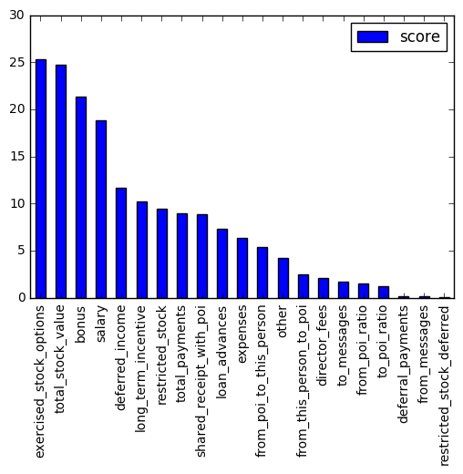

```python
b1.plot(kind = 'bar')
```

Select K Best help me to select bonus, salary, total_stock_value, and exercised_stock_options to create the model. I select 4 of them because there is a cutoff in the graph between 4th and 5th features. I selected 4 best of them to get most use of features. The two new features created by me - from_poi_ratio, to_poi_ratio are not selected.

## Model Selection and Tuning

```python
labels_1 = df.poi
```

```python
features_1 = df[['salary','bonus','total_stock_value','exercised_stock_options']]
```

I'm going to split the data into train and test dataset to do the validation. We will train the model on the training dataset and validate the model on test dataset. By doing this, we will not overfit the training data and we expect smiliar perfomance when we apply our model to other dataset. If we don't perform the validation, we will see very small errors when we train the model, but very large error when we apply the model to other population.

```python
#split train and test dataset
from sklearn.cross_validation import train_test_split
features_train, features_test, labels_train, labels_test = train_test_split(features_1, labels_1, test_size = 0.3)
```

Since this is a classification question, I'm going to use Decision Tree, Naive Bayes, Random forest and AdaBoost to train model and compare with each other in order to select the most accurate one.

Model Parameters tuning is very important because the change of each parameter will result in different permance of models. We want to get tuned parameters that give us the best performance. Since for every model, there are lots of parameters to be tuned, I'm using gridSearchCV to automatically tune the model parameters.

```python
#train Decision Tree Model
from sklearn.tree import DecisionTreeClassifier
from sklearn.grid_search import GridSearchCV
from sklearn.model_selection import StratifiedShuffleSplit

clf = DecisionTreeClassifier()
parameters = {'criterion': ['gini', 'entropy'],
               'min_samples_split': [2, 10, 20],
              'max_depth': [None, 2, 5, 10],
              'min_samples_leaf': [1, 5, 10],
              'max_leaf_nodes': [None, 5, 10, 20]}

grid_search = GridSearchCV(clf, parameters,scoring = 'recall')


grid_search.fit(features_train, labels_train)

print "Accuracy score:", grid_search.score(features_test,labels_test)

from sklearn.metrics import recall_score,precision_score
pred = grid_search.predict(features_test)
recall = recall_score(labels_test,pred)
precision = precision_score(labels_test,pred)

print "\nPrecision (POIs):", precision
print "Recall (POIs)", recall
```

```
Accuracy score: 0.142857142857

Precision (POIs): 0.333333333333
Recall (POIs) 0.142857142857
```

```python
#train Naive Bayes Model
from sklearn.naive_bayes import GaussianNB
from sklearn.grid_search import GridSearchCV

clf = GaussianNB()
parameters = {}
grid_search = GridSearchCV(clf, parameters,scoring = 'recall')
grid_search.fit(features_train, labels_train)

print "Accuracy score:", grid_search.score(features_test,labels_test)

from sklearn.metrics import recall_score,precision_score
pred = grid_search.predict(features_test)
recall = recall_score(labels_test,pred)
precision = precision_score(labels_test,pred)

print "\nPrecision (POIs):", precision
print "Recall (POIs)", recall
```

```
Accuracy score: 0.285714285714

Precision (POIs): 0.333333333333
Recall (POIs) 0.285714285714
```

```python
#train Random Forest Model
from sklearn.ensemble import RandomForestClassifier
from sklearn.grid_search import GridSearchCV

clf = RandomForestClassifier()
parameters = {"n_estimators"      : [250, 300],
           "criterion"         : ["gini", "entropy"],
           "max_features"      : [1, 4],
           "max_depth"         : [10, 20],
           "min_samples_split" : [2, 4] ,
           "bootstrap": [True, False]}
grid_search = GridSearchCV(clf, parameters,scoring = 'recall')
grid_search.fit(features_train, labels_train)

print "Accuracy score:", grid_search.score(features_test,labels_test)

from sklearn.metrics import recall_score,precision_score
pred = grid_search.predict(features_test)
recall = recall_score(labels_test,pred)
precision = precision_score(labels_test,pred)

print "\nPrecision (POIs):", precision
print "Recall (POIs)", recall
```

```
Accuracy score: 0.285714285714

Precision (POIs): 0.333333333333
Recall (POIs) 0.285714285714
```

```python
#train AdaBoost Model
from sklearn.ensemble import AdaBoostClassifier
from sklearn.grid_search import GridSearchCV

clf = AdaBoostClassifier()
parameters = {'n_estimators': [10, 20, 30, 40, 50],
               'algorithm': ['SAMME', 'SAMME.R'],
               'learning_rate': [.5,.8, 1, 1.2, 1.5]}
grid_search = GridSearchCV(clf, parameters,scoring = 'recall')
grid_search.fit(features_train, labels_train)

print "Accuracy score:", grid_search.score(features_test,labels_test)

from sklearn.metrics import recall_score,precision_score
pred = grid_search.predict(features_test)
recall = recall_score(labels_test,pred)
precision = precision_score(labels_test,pred)

print "\nPrecision (POIs):", precision
print "Recall (POIs)", recall
```

```
Accuracy score: 0.285714285714

Precision (POIs): 0.5
Recall (POIs) 0.285714285714
```